# evans_iLab02

Nathaniel Evans

October 20, 2018

```r
path_to_xlsx <- dryad_fetch(dryad_files(doi = '10.5061/dryad.7763s/1')) %>%
  pluck(1)
vitd <- read_xlsx(path_to_xlsx, sheet = 1)
vitd <- vitd %>%
  clean_names()
#glimpse(vitd)

codebook <- read_xlsx(path_to_xlsx, sheet = 2)

lm_vars <- c("sex", "_zhfa", "ageyears", "_25D")
codebook %>%
  filter(Variable %in% lm_vars) %>%
  knitr::kable()
```

| Variable | Description | Unit or coding where applicable |
| --- | --- | --- |
| sex | Sex of child participant | F=female, M=male |
| ageyears | Age of child participant | YEARS |
| _zhfa | Height-for-age z-score | Standard deviation (SD) |
| _25D | Serum 25-hydroxyvitamin D concentrations | nmol/L |

```r
lm_data <- vitd %>% select(c("sex", "zhfa", "ageyears", "x25d"))
```

# EDA

```r
glimpse(lm_data)
```

```
## Observations: 537
## Variables: 4
## $ sex      <chr> "F", "F", "F", "F", "M", "M", "M", "F", "F", "F", "M"...
## $ zhfa     <dbl> -0.58, -0.12, -0.98, -1.20, -1.45, -0.77, 0.34, -0.33...
## $ ageyears <dbl> 7.749487, 7.040383, 7.289528, 7.251198, 6.845995, 7.7...
## $ x25d     <dbl> 72.2, 73.4, 64.6, 73.6, 88.5, 85.8, NA, 75.2, 82.9, 7...
```

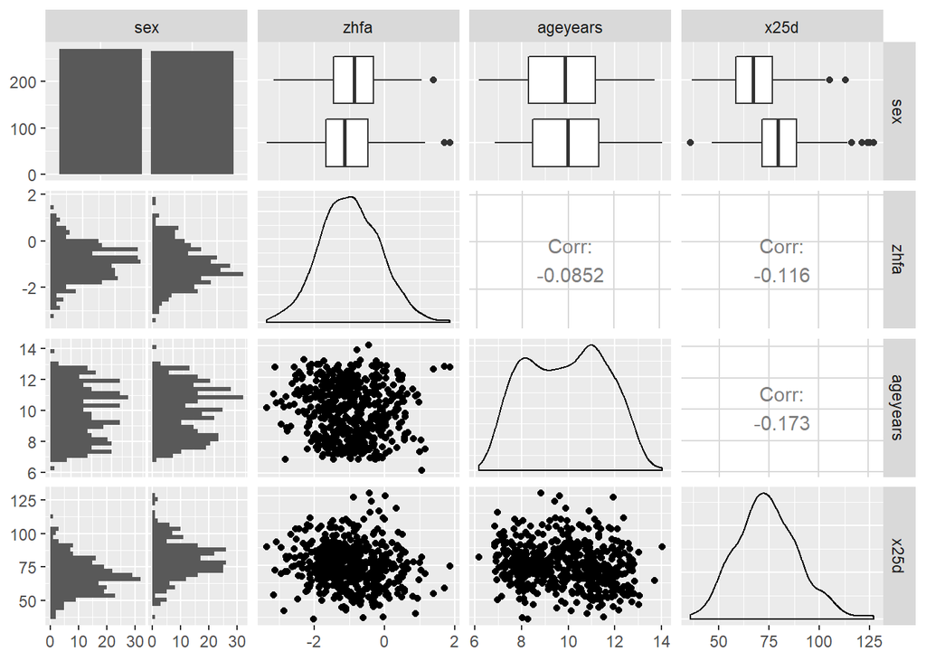

```r
ggpairs(data=lm_data)
```

## GGpair analysis

Weak inverse correllation x25d and zhfa and age, but significant difference in x25d values between sex so an interaction model may be valuable. x25d exhibits some kurtosis and age seems to have two modes, which deserces some looking into (especially if the modes correllate to male/female - might explain diff in sex x25D and sex data).

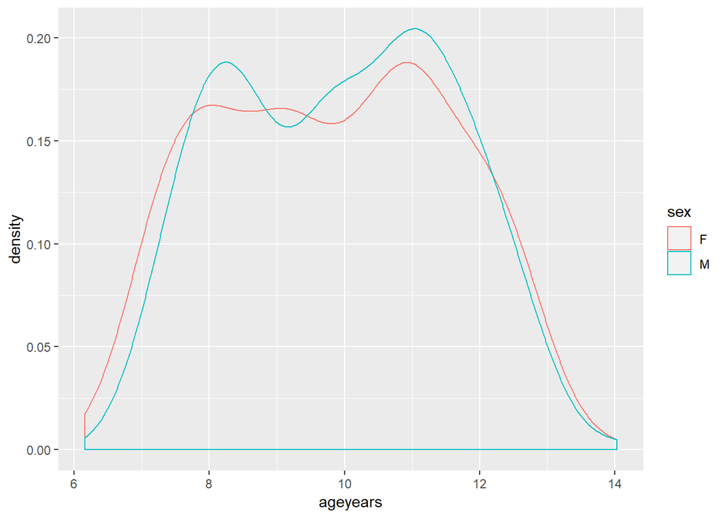

```r
lm_data %>% group_by(sex) %>% ggplot(aes(x = ageyears, color=sex)) + geom_density()
```

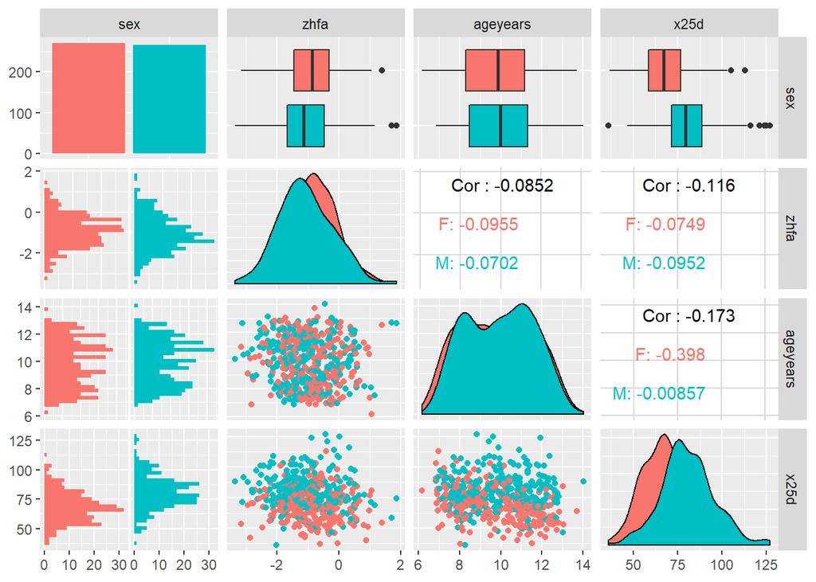

```r
lm_data %>% ggpairs(aes(color=sex))
```

The bimodality doesn’t seem to be attributed to sex distribution, I think this is important to explore more.

```r
lm_data %>% skimr::skim()
```

```
## Skim summary statistics
##  n obs: 537
##  n variables: 4
##
## -- Variable type:character --------------------------------------------------------------------------------------------------
##  variable missing complete   n min max empty n_unique
##       sex       0      537 537   1   1     0        2
##
## -- Variable type:numeric ----------------------------------------------------------------------------------------------------
##  variable missing complete   n  mean    sd    p0   p25   p50   p75   p100
##  ageyears       0      537 537  9.89  1.69  6.16  8.38  9.95 11.26  14.03
##      x25d       8      529 537 74.31 15.39 36.1  64.3  73.6  84.3  127
##      zhfa       0      537 537 -0.98  0.84 -3.35 -1.57 -1    -0.36   1.86
##      hist
##  ▁▇▇▇▇▇▅▁
##  ▁▃▆▇▅▂▁▁
##  ▁▂▆▇▆▃▁▁
```

```r
lm_data %>% summary()
```

```
##      sex                 zhfa            ageyears           x25d
##  Length:537         Min.   :-3.3500   Min.   : 6.159   Min.   : 36.10
##  Class :character   1st Qu.:-1.5700   1st Qu.: 8.379   1st Qu.: 64.30
##  Mode  :character   Median :-1.0000   Median : 9.951   Median : 73.60
##                     Mean   :-0.9827   Mean   : 9.887   Mean   : 74.31
##                     3rd Qu.:-0.3600   3rd Qu.:11.265   3rd Qu.: 84.30
##                     Max.   : 1.8600   Max.   :14.025   Max.   :127.00
##                                                        NA's   :8
```

#### How many variables/columns?

We are considering only 4 variables: ageyears, x25d, sex, zhfa

#### How many rows/observations?

There are 537 observations.

#### Which variables are numbers?

age x25d zhfa

#### Which are categorical variables (numeric or character variables with variables that have a fixed and known set of possible values; aka factor variables)?

sex [“M”/“F”]

#### Complete this sentence: “There is one row/observation per.”

school child in thailand

#### What are the correlations between variables? Does each scatterplot support a linear relationship between variables? Do any of the correlations appear to be conditional on the value of a categorical variable (like sex)?

From initial EDA, the scatterplots do not show an obvious linear correllation however the cor() function shows a slight negative correlation between the variables. sex plays a significant role in mediating the ageyears variable correlation; females show a high correllation between age and x25d.

```r
#lm_dataz <- lm_data %>% transmute(sex = sex, age = scale(lm_data$ageyears,center=TRUE, scale=TRUE), hgt_age= scale(lm_data$zhfa,center=TRUE, scale=TRUE), vitD = scale(lm_data$x25d, center=TRUE, scale=TRUE))

#glimpse(lm_dataz)

vitD_mod <- lm(data=lm_data, formula= 'x25d ~ ageyears*sex + zhfa')

vitD_mod
```

```
##
## Call:
## lm(formula = "x25d ~ ageyears*sex + zhfa", data = lm_data)
##
## Coefficients:
##   (Intercept)       ageyears           sexM           zhfa  ageyears:sexM
##        96.937         -3.090        -16.814         -1.728          2.964
```

```r
get_regression_summaries(model=vitD_mod)
```

```
## # A tibble: 1 x 8
##   r_squared adj_r_squared   mse  rmse sigma statistic p_value    df
##       <dbl>         <dbl> <dbl> <dbl> <dbl>     <dbl>   <dbl> <dbl>
## 1     0.236          0.23  181.  13.4  13.5      40.5       0     5
```

```r
model_pts <- get_regression_points(model=vitD_mod)
```

## Regression Model

My regression model is described (names altered) as:
$$VITD = -3.1*AGE - 16.8*SEX_m - 1.73*zHFA + 3.0*AGE*SEX_m + 96.9$$

| VAR | MIN | MAX |
| --- | --- | --- |
| AGE | 6.2 | 14.0 |
| zhfa | -3.4 | 1.8 |
| x25D | 36 | 127 |

With these bounds in mind, the intercept is the offset that best fits the data while the correllation coefficients determine how the data behaves within these bounds. So, as an example, for a child who is 6.2 years old, has zhfa of -3.4, the intercept compensates to bring the x25D value to within the fitted range.